# DSCOE Inferno Code Challenge

Ian Kloo

July 2016

# Background

This coding challenge comes from a real problem that our division faced recently that highlights the usefulness of open-source techniques. The problem required that we find how close certain things on a map were to other things. I know…vague. While I can’t discuss the specifics here, you can imagine that this is a type of question that is asked often: how many events occurred near some location(s)?

This is a pretty classic problem in the GIS space, but when we received the request to do this analysis, our GIS guru was out of the office. Unfortunately, this is not the type of problem that can easily be solved using the traditional tools (Excel) that are readily available on high-classification systems.

In order to solve the problem, we created an unclassified facsimile of the real data. This allowed us to work on unclassified systems (so much easier!) and move up our solution once it was completed. You will recreate our analysis as part of this code challenge - hopefully coming up with new, easier, faster, or just plain better ways than we came up with!

# The Challenge

**Your task is to create a visualization that shows the distance of each Starbucks store from each city center.**

If you complete this task, here are some next steps you can work on (no need to do them in order):

1. Create a markdown file that explains and documents your code.
2. If your first visualization(s) aren’t interactive, make them interactive!
3. Create a shiny app that allows for further interaction.
4. Deploy your shiny app on an AWS instance as a means of sharing your app.

# Basic Roadmap

You absolutely do not need to follow any specific procedure, but here is a roadmap of how I would attack this problem:

- Read in and clean data
- Calculate distances between city centers and starbucks (all of them)
- Map the results – Pick the right map area – Plot a symbol for each starbucks and city center – Find a way to differentiate dots based on their distance from the city center(s)

If you do choose to follow this path, I will provide some hints and solutions to make sure you are on the right track.

On the other hand, you can certainly go it alone from the start - you just won’t find much support from the rest of these instructions.

# Reading and cleaning data

As with any real data science task, you first need to find a way to get the data! We could give you fully cleaned and prepped data, but what is the fun in that?

To keep us roughly on the same page, here is a raw data set that will help with the starbucks store locations: https://www.google.com/fusiontables/DataSource?docid=1D4kfAMzX3FME8MkR9rVhd9rJ9gKEP00XZqiyQCc#rows:id=1. Your challenge is getting this data into R successfully.

Show Hint

I will leave you to find the data you need for the cities, as this should be pretty standard. You will need the lat and lon of the city centers of these cities: Annapolis, Baltimore, Richmond, DC, and Philadelphia.

Show Hint

The end result you want to get to here is 2 data frames: one with the lat, lon, and address of each starbucks location and one with the lat, lon, and name of each city. The lat/lon fields should be numeric and the others should be characters (not factors!!!).

**Important!** If you are not familiar with GIS, make sure you consider the notation that different sources will use for lat/lon. Specifically, some will show coordinates using cardinal directions while others will use +/- notation. For example, these two are equivalent:

38.9072° N, 77.0369° W = 38.9072°, -77.0369°

Make sure your data sets are using the same notation!

## Code Check #1

If you want to be able to follow our solution code in the next sections, you will need to start out with data sets that look **exactly** like the two below. One must be named “cities” and one must be named “starbucks”. Remember, the lat/lon fields must be numeric and all others should be characters.

If you aren’t worried about checking your code, just move to the next step.

|  | lat | lon | address |
| --- | --- | --- | --- |
| 1 | 21.879285 | -159.459214 | 2360 Kiahuna Plantation Drive&lt;br&gt;Koloa, HI 96756&lt;br&gt;(808) 742-5144 |
| 2 | 21.97116 | -159.380923 | 3-2600 Kaumualii Highway #A8&lt;br&gt;Lihue, HI 96766&lt;br&gt;(808) 241-7034 |
| 3 | 21.971295 | -159.375636 | 4303 Nawiliwili Road&lt;br&gt;Lihue, HI 96766&lt;br&gt;(808) 245-7562 |
| 4 | 21.979465 | -159.34927 | LihueAirport Unit 2 3901 Mokulele Loo&lt;br&gt;Lihue, HI 96766-970&lt;br&gt;(808) 245-8913 |
| 5 | 22.078248 | -159.315957 | 4-831 Kuhio Highway #208&lt;br&gt;Kapaa, HI 96746&lt;br&gt;(808) 821-1334 |
| 6 | 21.434788 | -158.18458 | 86 Farrington Highway&lt;br&gt;Waianae, HI 96792&lt;br&gt;(808) 697-8279 |
| 7 | 21.343991 | -158.116013 | 563 Farrington Highway #101&lt;br&gt;Kapolei, HI 96707&lt;br&gt;(808) 674-8735 |
| 8 | 21.3341 | -158.08179 | 338 Kamokila Boulevard #108&lt;br&gt;Kapolei, HI 96797&lt;br&gt;(808) 674-1941 |
| 9 | 21.648414 | -158.061706 | 59-720 Kamehameha Highway&lt;br&gt;Haleiwa, HI 96712&lt;br&gt;(808) 638-0341 |
| 10 | 21.483994 | -158.058557 | Bldg. 693&lt;br&gt;Schofield Barracks, HI 96857-720 |

[output cut: 11590 more lines]

|  | city | lat | lon |
| --- | --- | --- | --- |
| 1 | Washington, DC | 38.9072 | -77.0369 |
| 2 | Philadelphia | 39.9526 | -75.1652 |
| 3 | Richmond | 37.5407 | -77.436 |
| 4 | Baltimore | 39.2904 | -76.6122 |
| 5 | Annapolis | 38.9784 | -76.4922 |

Show Solution

OK, here is how we got to this point:

1. On the link provided to the starbucks locations, click “file” and “download”. Select the “CSV” option and save this to your working directory as ‘Starbucks.csv’.
2. Open up Excel and make a row for each city. Then google each city followed by coordinates (e.g., “washington DC coordinates”) to get the coordinates. Remember to convert from E/W notation to +/- notation.
3. Save this file in CSV format as ‘cities.csv’.
4. Use the following code to read in your data sets and rename the columns. Note, we use the ‘stringsAsFactors’ argument to make sure R doesn’t convert things to factors.

```r
cities <- read.csv('cities.csv', stringsAsFactors=FALSE)
starbucks <- read.csv('Starbucks.csv', stringsAsFactor=FALSE)

colnames(cities) <- c('city','lat','lon')
colnames(starbucks) <- c('lat','lon','address')
```

# Calculating Distances

Now that you have your two data frames, it is time to calculate the distances between each starbucks store and city center.

The first thing you will need to figure out is how to calculate the distances between points using lat/lon. You shouldn’t have a hard time finding this info with some quick google searching.

Show Hint

Here is what our final distance data frame looks like:

|  | Latitude | Longitude | Address | WashDist | PhilDist | RichDist | BaltDist | AnnaDist |
| --- | --- | --- | --- | --- | --- | --- | --- | --- |
| 8345 | 38.48094 | -82.644008 | 1201 Winchester Avenue&lt;br&gt;Ashland, KY 41101&lt;br&gt;(606) 329-0010 | 304.096651260737 | 413.37715370731 | 291.143360473959 | 329.492574769501 | 333.668227772492 |
| 8398 | 36.542989 | -82.519565 | 1860 N Eastman Road&lt;br&gt;Kingsport, TN 37664&lt;br&gt;(423) 245-3749 | 341.553970057715 | 463.692381344191 | 288.990753251379 | 374.085769711091 | 370.046062045452 |
| 8412 | 36.549955 | -82.493433 | 2626 E Stone Dr&lt;br&gt;Kingsport, TN 37660&lt;br&gt;(423) 578-1726 | 340.056948738133 | 462.210810268977 | 287.462891884767 | 372.601058117752 | 368.541930406064 |
| 8431 | 38.42207 | -82.444267 | 285 9th Street&lt;br&gt;Huntington, WV 25701&lt;br&gt;(304) 697-0217 | 293.926701584095 | 404.223719884962 | 279.739631641811 | 319.772269967042 | 323.54530884632 |
| 8435 | 40.086181 | -82.421453 | 243 Deo Drive&lt;br&gt;Newark, OH 43055&lt;br&gt;(740) 366-3384 | 298.697760649937 | 384.388397426728 | 321.168909188198 | 314.020732746409 | 325.398316065112 |
| 8451 | 36.34097 | -82.375202 | 2008 North Roan St&lt;br&gt;Johnson City, TN 37604&lt;br&gt;(423) 283-0818 | 342.023270243407 | 464.774245706566 | 285.353939350613 | 375.098962106186 | 370.103250081533 |
| 8471 | 38.415077 | -82.299017 | 6360 US Route 60&lt;br&gt;Barboursville, WV 25504 | 286.20870932772 | 396.86748327213 | 271.923630978591 | 312.203253692306 | 315.839885758975 |
| 8473 | 38.421919 | -82.288981 | 900 Lauren Christian Drive&lt;br&gt;Barboursville, WV 25504&lt;br&gt;(304) 736-7243 | 285.601323906013 | 396.205188773833 | 271.484090089886 | 311.567296896175 | 315.229599957678 |
| 8477 | 38.421126 | -82.262092 | 1 Mall Rd&lt;br&gt;Barboursville, WV 25504&lt;br&gt;(304) 733-4383 | 284.167805064118 | 394.834141002212 | 270.045246361475 | 310.15923073902 | 313.798140924486 |
| 8497 | 36.632171 | -82.122703 | 3177 Lee Highway&lt;br&gt;Bristol, VA 24201&lt;br&gt;(276) 696-0070 | 319.445897464262 | 441.859421366315 | 266.102614913889 | 352.206508069616 | 347.79553567173 |

[output cut: 2208 more lines]

If you give up, or are just curious about how I went about this step, click below to show our solution.

Show Solution

Here’s how I went about solving this problem.

```r
library(stringr)

colCount <- 4
for(i in 1:nrow(cities)) {
  dist <- distHaversine(starbucks[,c('Longitude', 'Latitude')], cities[i,c('Lon','Lat')])
  miles <- dist*.000621371
  starbucks <- cbind(starbucks, miles)
  colnames(starbucks)[colCount] <- paste(str_sub(cities$City[i],end=4), 'Dist', sep='')
  colCount <- colCount + 1
}

starbucks <- starbucks[starbucks$WashDist <= 300 |
                         starbucks$PhilDist <= 300 |
                         starbucks$RichDist <= 300 |
                         starbucks$BaltDist <= 300 |
                         starbucks$AnnaDist <= 300,]
```

You can see that I used a for-loop, but don’t be scared off by that! You could easily just write out this procedure for every city individually, but it saves space to loop instead. Additionally, this code now scales so that you could theoretically run it over many cities without having to change your code.

The procedure within the loop is to calculate the distance between every starbucks store and a city center, convert that distance to miles, then create a new column with the distances (named according to the city). The final chunk of code removes any stores that are not within 300 miles of any of the cities.

The trickiest thing here is the naming of the columns. I used the str_sub() function from the stringr library to take only the first 4 characters of each city name. I then used the paste() function to add on the word “Dist” at the end to create descriptive column names.

You don’t have to follow this code exactly! Just make sure your data frame looks something like what we have above if you want to keep following along.

# Map the results

There are a number of different ways that you can map things in R - you can use any way that you want! I will show 2 solutions that I am familiar with: maps and ggmaps.

There are a few different ways to go about this problem - if you have a good idea, try it!

The first thing that comes to mind for me is to create a map for each city and use color or opacity to differentiate distance. No matter how you go about this, it might be useful to just limit to one city at first to test your methods.

## Maps package

One easy way to plot simple maps in R is the maps package. I will leave the coding up to you - here is what my solution looks like for DC only. I decided to use green to show stores within 50 miles, blue to show stores within 100 miles, and red to show stores within 300 miles.

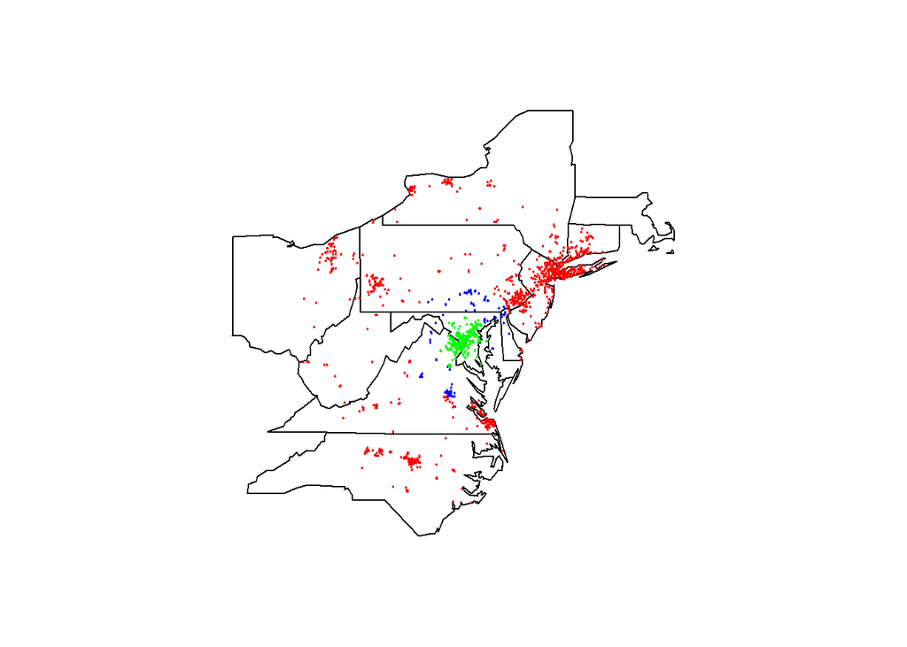

Show Hint

Show Solution

Here’s how I went about solving this problem.

```r
starbucks$colWash <- NA
starbucks$colWash[starbucks$WashDist < 300] <- 'red'
starbucks$colWash[starbucks$WashDist < 100] <- 'blue'
starbucks$colWash[starbucks$WashDist < 50] <- 'green'

library(maps)
  map('state', regions=c(".*maryland", '.*washington dc', '.*virginia', '.*pennsylvania', ".*delaware", ".*new york", ".*ohio", ".*new jersey", ".*connec", ".*north carolina", ".*mass"))
points(starbucks[,c(2,1)], cex=.2, col=starbucks$colWash)
```

First, I created a variable to hold the values for the colors called colWash. I added this as a column to the data frame. Next, I assigned values to that variable based on the distance from Washington DC.

For the maps part, I used the map() function to draw a basic map with all surrounding states. Then, I filled in the points using the points() function, specifying the size of the points with the cex argument and the color with the col argument.

## ggmap

Now, lets try to replicate what we did before in ggmap. The ggmap package has pretty good documentation out there, so you should start with a search.

Show Hint

Here’s what I got for Washington, DC:

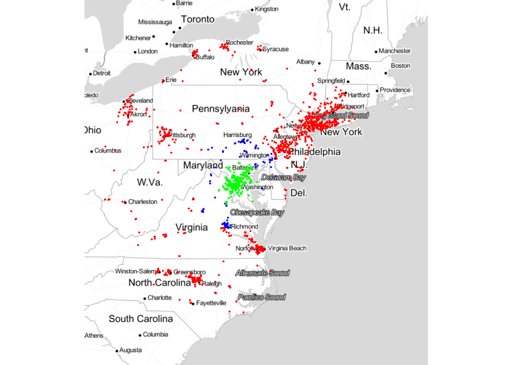

Show Solution

Here’s how I went about solving this problem.

```r
starbucks$colWash <- NA
starbucks$colWash[starbucks$WashDist < 300] <- 'red'
starbucks$colWash[starbucks$WashDist < 100] <- 'blue'
starbucks$colWash[starbucks$WashDist < 50] <- 'green'

library(ggmap)
qmplot(Longitude, Latitude, data=starbucks, size=I(.5), color=I(starbucks$col))
```

The first steps here should be familiar since they were borrowed from the maps package solution.

With the final function, qmplot(), it is a fairly easy way to draw maps that look good right away. I would caution, however, that if ggmaps doesn’t do something the way you like by default, it can be a real headache to change things like colors, scales, labels, etc.

### Advanced Method - Saving Maps in a Loop

Try to replicate this for all of the cities. Maybe, it would be useful to create a loop to do this for any number of cities, saving maps as .png files as it goes along. If you’re interested, give that a shot and check your code against the solution below.

Show Solution

```r
varList <- colnames(starbucks)[grep('Dist', colnames(starbucks))]
for(i in 1:length(varList)) {
  starbucks$col <- NA
  starbucks$col[starbucks[varList[i]] < 300] <- 'red'
  starbucks$col[starbucks[varList[i]] < 100] <- 'blue'
  starbucks$col[starbucks[varList[i]] < 50] <- 'green'

  fileName <- paste(str_sub(varList[i], end=4), 'Map.png', sep='')
  png(fileName)

  map <- qmplot(Longitude, Latitude, data=starbucks, size=I(.5), color=I(starbucks$col))
  plot(map)

  dev.off()
}
```

The key changes that I had to make between the one-off solution and the for loop are:

1. Create a variable called varList that equals all of the column names for all cities. This is the trickiest part of the code because it needs to be robust to any number of cities. I used the grep() function to find every column name that ends in “Dist” to make this robust to any number of cities.
2. Make a generic column called “col” to hold the color values - this will be overwritten each time through the loop.
3. Make a filename for each map - it must be different so that we aren’t just saving over our original map.
4. I used the png() function which writes the next plot/map to the working directory as a .png file. Note, you must use dev.off() to tell R to stop writing things to the working directory.

If you run this code, you will find 5 maps saved as png files in your working directory.

## Next Steps

If you were able to get this far, congratulations! If you’re interested, here are some suggestions for future work on this problem/topic:

### Create Documentation

Everyone thinks differently, so everyone writes and reads code differently. Even if your code makes perfect sense to you, you may be the only one who gets it.

Commenting code is a great way to explain what you are doing, but sometimes it falls short. Consider taking the next steps and documenting your methodology in RMarkdown.

RMarkdown lets you create documents that include R code and run R code. This document is an RMarkdown document.

If you want to learn how to make these (its very easy), head on over to the documentation/tutorial here: http://rmarkdown.rstudio.com/. All you need is R Studio and a little bit of patience.

### Make your Maps Interactive

The most widely used mapping package (or at least the one I’ve seen the most) for the web is called Leaflet. Leaflet is actually a javascript library, but there is an R package that lets you quickly and easily plot in code that looks a lot like what we showed above. The added benefits of leaflet come from interactivity. By default, users can zoom and pan around your map. Also, it is possible to add advanced features such as on-click behavior and interactive legends.

### Make a Shiny App

To add even more interactivity, consider making a shiny app! I won’t go through the gory details here, but shiny apps are basically javascript applications that you write without having to know any javascript. Think about it this way: using shiny, you write R code that becomes the back-end of an interactive website.

Check out the shiny tutorial (which is excellent) here: http://shiny.rstudio.com/.

### Deploy Your Shiny App

I really don’t expect anyone to still be interested at this point, but if you want to know what the next logical step is, it would be to deploy the app you just made in some way. The simplest way to do this (in my opinion) is through Amazon Web Services.

There are a wealth of resources online, but this will take you a lot of trial and error.